# Wellness Technology Plays It Smart | Case Study

Bao Huynh

2023-01-31

**Business task:** To help unlock the new growth opportunities for Bellabeat, a successful small company in wearable tech, we analyze smart device fitness data and gain insights into how consumers use their smart devices.

These questions will guide our analysis are:

1. What are some trends in smart device usage?
2. How could these trends apply to Bellabeat customers?
3. How could these trends help influence Bellabeat’s marketing strategy?

**Data sources:** Fitbit Fitness Tracker Data (CC0: Public Domain, dataset made available through Mobius). It includes information about daily activity, steps, and heart rate that can be used to explore users’ habits.

A few limitations noted upon inspect following data are:

- Number of participants are limited (33)
- There is no break out of gender

**Analysis Summary:** The analysis will use Rstudio and R for data wrangling and analysis The processes is documented below.

Loading packages

```r
library(tidyverse)
library(lubridate)
```

Importing Dataset

```r
activity <- read.csv("Source-data/GOOG_DA_P2/dailyActivity_merged.csv")
intensity <- read.csv("Source-data/GOOG_DA_P2/dailyIntensities_merged.csv")
intensityHr <- read.csv("Source-data/GOOG_DA_P2/hourlyIntensities_merged.csv")
sleep <- read.csv("Source-data/GOOG_DA_P2/sleepDay_merged.csv")
weight <- read.csv("Source-data/GOOG_DA_P2/weightLogInfo_merged.csv")
```

Using head() function to review imported data

```r
head(activity)
```

[output not shown]

Some inconsistencies were spotted with timestamp data, parse field into date and time

```r
#activity
activity$ActivityDate <- as.POSIXct(activity$ActivityDate, format="%m/%d/%Y", tz=Sys.timezone())
activity$date <- format(activity$ActivityDate, format = "%m/%d/%y")
#hourly intensity
intensityHr$ActivityHour <- as.POSIXct(intensityHr$ActivityHour, format="%m/%d/%Y %I:%M:%S %p", tz=Sys.timezone())
intensityHr$time <- format(intensityHr$ActivityHour, format = "%H:%M:%S")
intensityHr$date <- format(intensityHr$ActivityHour, format = "%m/%d/%y")
#sleep
sleep$SleepDay=as.POSIXct(sleep$SleepDay, format="%m/%d/%Y %I:%M:%S %p", tz=Sys.timezone())
sleep$date <- format(sleep$SleepDay, format = "%m/%d/%y")
#weight
weight$Date<- as.POSIXct(weight$Date, format="%m/%d/%Y %I:%M:%S %p", tz=Sys.timezone())
weight$time <- format(weight$Date, format = "%H:%M:%S")
weight$date <- format(weight$Date, format = "%m/%d/%y")
```

Exploring summary of dataset

```r
n_distinct(activity$Id)
```

```
## [1] 33
```

```r
n_distinct(intensity$Id)
```

```
## [1] 33
```

```r
n_distinct(sleep$Id)
```

```
## [1] 24
```

```r
n_distinct(weight$Id)
```

```
## [1] 8
```

This result is telling us, there are 33 participants in activity dataset, 33 participant in intensity dataset, 24 participants in sleep dataset, and 8 participants in weight dataset. Let look at some stastistic summary!

```r
#activity
activity %>%
  select(TotalSteps,
         TotalDistance,
         SedentaryMinutes,
         Calories) %>%
  summary()
```

```
##    TotalSteps    TotalDistance    SedentaryMinutes    Calories
##  Min.   :    0   Min.   : 0.000   Min.   :   0.0   Min.   :   0
##  1st Qu.: 3790   1st Qu.: 2.620   1st Qu.: 729.8   1st Qu.:1828
##  Median : 7406   Median : 5.245   Median :1057.5   Median :2134
##  Mean   : 7638   Mean   : 5.490   Mean   : 991.2   Mean   :2304
##  3rd Qu.:10727   3rd Qu.: 7.713   3rd Qu.:1229.5   3rd Qu.:2793
##  Max.   :36019   Max.   :28.030   Max.   :1440.0   Max.   :4900
```

```r
activity %>%
  select(VeryActiveMinutes,
         FairlyActiveMinutes,
         LightlyActiveMinutes) %>%
  summary()
```

```
##  VeryActiveMinutes FairlyActiveMinutes LightlyActiveMinutes
##  Min.   :  0.00    Min.   :  0.00      Min.   :  0.0
##  1st Qu.:  0.00    1st Qu.:  0.00      1st Qu.:127.0
##  Median :  4.00    Median :  6.00      Median :199.0
##  Mean   : 21.16    Mean   : 13.56      Mean   :192.8
##  3rd Qu.: 32.00    3rd Qu.: 19.00      3rd Qu.:264.0
##  Max.   :210.00    Max.   :143.00      Max.   :518.0
```

On average, each participants has 991 minutes (16 hrs) in sedentary. This indicate our participants are quite inactive throughout their days, with majority being lightly active. We need to reduce sedentary minutes desperately!!!

Average total steps per day are 7638 which a little bit less for having health benefits for according to the CDC research. The CDC recommend that most adults aim for 10,000 steps per day. There is room to improve in step counts!!!

```r
# sleep
sleep %>%
  select(TotalSleepRecords, TotalMinutesAsleep, TotalTimeInBed) %>%
  summary()
```

```
##  TotalSleepRecords TotalMinutesAsleep TotalTimeInBed
##  Min.   :1.000     Min.   : 58.0      Min.   : 61.0
##  1st Qu.:1.000     1st Qu.:361.0      1st Qu.:403.0
##  Median :1.000     Median :433.0      Median :463.0
##  Mean   :1.119     Mean   :419.5      Mean   :458.6
##  3rd Qu.:1.000     3rd Qu.:490.0      3rd Qu.:526.0
##  Max.   :3.000     Max.   :796.0      Max.   :961.0
```

On the average, participants sleep 1 time for 7 hours.

Before visualize data, we merge activity with sleep dataset

```r
sleepVsActivity <- merge(sleep, activity, by = c("Id", "date"))
```

Let’s look at the relationship between Sedentary and Sleep

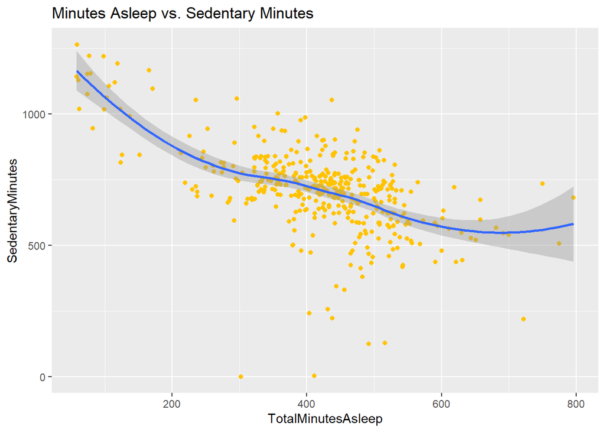

```r
ggplot(data = sleepVsActivity, aes(x=TotalMinutesAsleep, y=SedentaryMinutes)) +
geom_point(color= "#ffc300" ) + geom_smooth() +
  labs(title="Minutes Asleep vs. Sedentary Minutes")
```

Here we see a negative relationship between Sedentary Minutes and Sleep Minutes. This suggests that if participants want to improve Sleep, they should be recommended to reduce sedentary. This insight should be investigate further to determine proper correlation and causation between data points.

Let’s take a look at our participant Intensity during the day

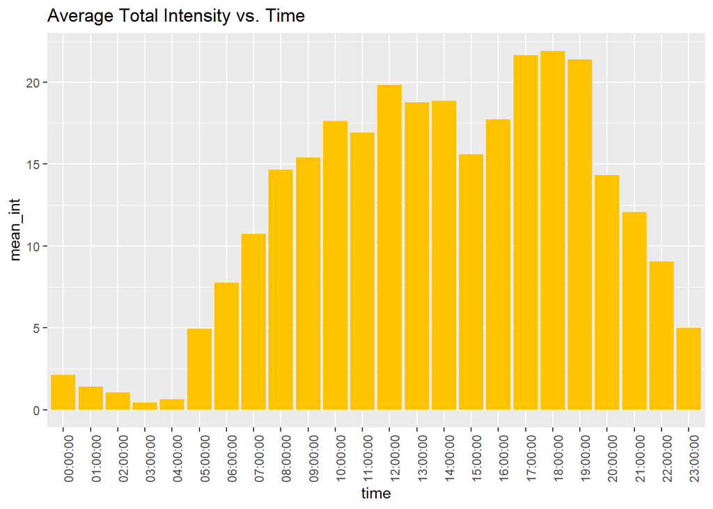

```r
int <- intensityHr %>%
  group_by(time) %>%
  drop_na() %>%
  summarise(mean_int = mean(TotalIntensity))

ggplot(data=int, aes(x=time, y=mean_int)) + geom_histogram(stat = "identity", fill="#ffc300") +
  theme(axis.text.x = element_text(angle = 90)) +
  labs(title="Average Total Intensity vs. Time")
```

According to this viz, our people are more active between 5AM and 10PM with most activity peak around 5PM to 7PM. We can develope a reminder to encourage people to active beside these hours.

**Suggestion:** -Average total steps per day are 7638 which a little bit less for having health benefits for according to the CDC research. The CDC recommend that most adults aim for 10,000 steps per day. They found that taking 8,000 steps per day was associated with a 51% lower risk for all-cause mortality (or death from all causes). Taking 12,000 steps per day was associated with a 65% lower risk compared with taking 4,000 steps. Bellabeat can encourage people to take at least 8,000 steps a day

-Most activity happens between 5 pm and 7 pm. Bellabeat can use this time to remind and motivate users to go for a run or walk beside these hours

-The negative relationship between Sedentary Minutes and Sleep Minutes suggests that if participants want to improve Sleep, they should be recommended to reduce sedentary by being more active througout the day. As a result, Bellabeat should consider using app notifications to go to bed.